## Прогнозирование эффективности каналов привлечения пользователей.

выполнил: *Григорий Михолап*  
дата: *18/01/2016*

**Задание:**

Существует четыре рекламных канала прихода пользователей A, B, C и D. В сентябре канал D был удален, и по май включительно существовало только три рекламных канала. В июне предполагается снова ввести рекламный канал D. Необходимо определить будущее значение пользователей с этого канала в июне. Количество регистраций по периодам на каждом канале представлено в файле “Data.xls” на вкладке “Рекламные каналы”.

**Выводы кратко:** Прогноз для остановленного канала выполнен на основании данных о результативности данного канала в первые 3 месяца его работы с учетом тренда (рассчитанного на основании данных по 3-м работающим каналам). Спрогнозированное на июнь количество регистраций равно `290`. Подробности см. в отчете ниже.

**Замечание** по поводу программного кода: Программный код, который используется в отчете, в т.ч. и некоторые операции (такие как загрузка и подготовка данных для анализа) не были включены в отчет, при необходимости все эти данные вы можете найти [по ссылке](https://github.com/Grag2015/testInfotech/blob/master/Task%202%20advert%20channels.Rmd)

Замечание: месяцы в загруженном датафрейме были расположены в хронологическом порядке - “июнь”, “июль”, “август”, “сентябрь”, “октябрь”, “ноябрь”, “декабрь”, “январь”, “февраль”, “март”, “апрель”, “май”.

## Анализ данных

Посмотрим на средние показатели предоставленных данных

| Показатель | Канал A | Канал B | Канал С | Канал D | Все каналы |
| --- | --- | --- | --- | --- | --- |
| Среднее число регистраций в месяц | 480 | 620 | 359 | 220 | 486 |
| Среднее отклонение | 58 | 45 | 13 | 22 | 33 |

Мы видим, что канал `B` наиболее результативный, на втором месте канал `A`, на третьем канал `C`. Канал `D`, значение по которому предстоит спрогнозировать показал за 3 месяца относительно невысокие показатели, и привел в июне-августе порядка 15% от всех регистраций за эти месяцы. Однако, важно отметить, что кроме числа регистраций, необходимо еще учитывать и стоимость привлечения одной регистрации, возможно по этому показателю канал D может быть интересен. Впрочем, анализ эффективности каналов выходит за рамки данного отчета.

Далее, посмотрим на показатели регистрации по каналам во временной динамике (см. диаграмму)

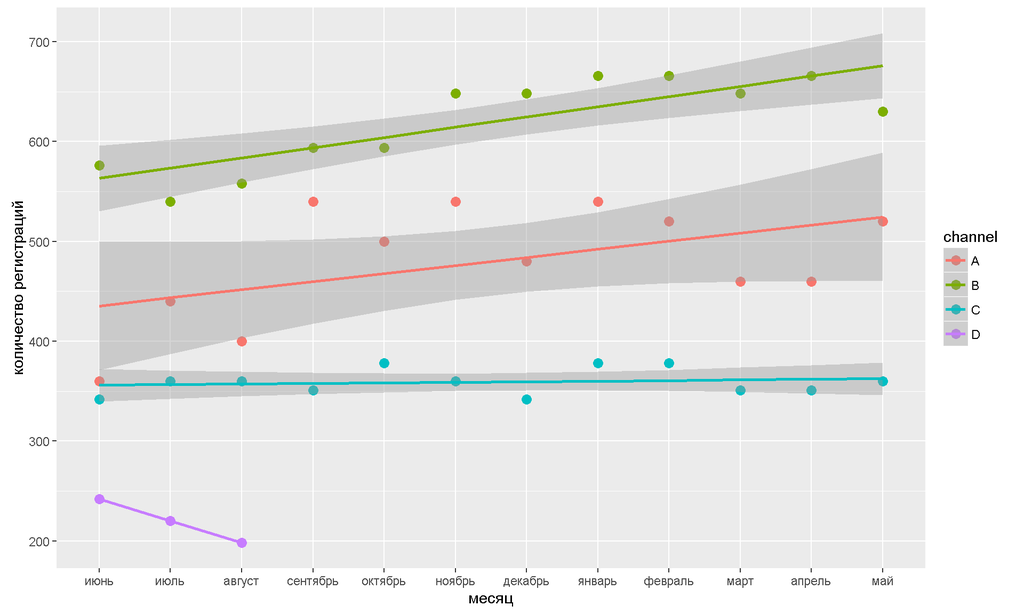

Мы видим, что каналы `А` и `В` показывают положительную динамику, а канал `С` оставался примерно на одном уровне в течение 12 месяцев. Можно сказать, что в целом *наблюдается положительный тренд по показателям регистрации*. Следует заметить, что канал `D` показал за 3 месяца отрицательную динамику, однако из-за небольшого периода наблюдений мы не можем делать какие-либо выводы на основании этого факта.

Далее, посмотрим есть ли зависимость между данными по разным каналам. Для этого рассчитаем коэффициенты детерминации и посмотрим на данные на матрице попарных корреляций. Внимание! в клетках верхней диагонали рассчитаны коэффициенты корреляции между соответствующими парами.

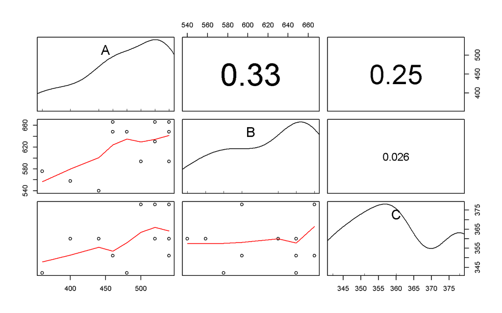

Как видим, нет сильных связей между данными по различным каналам. Будем считать, что каналы работают незавимо: никто не перетягивает регистрации на себя и наборот.

Теперь посмотрим на среднее число регистраций по каналам `А`, `В` и `С` (см. график ниже)

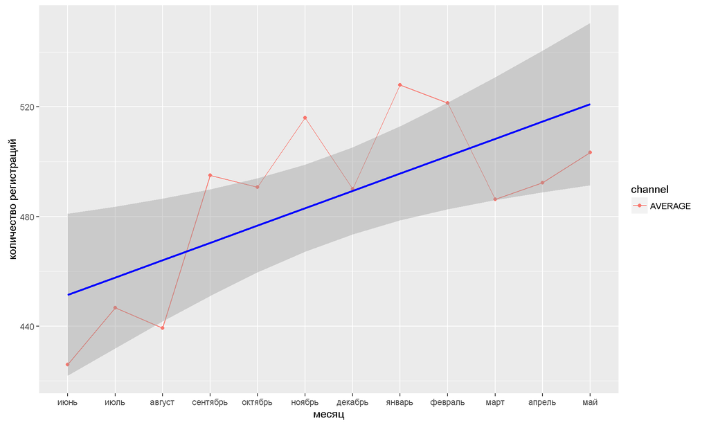

На данном графике мы видим некоторые (вполне объяснимые) сезонные колебания, например, предновогоднее падение в декабре, а также резкое падение в марте, возможно связанное с также с праздниками. Но все-таки у нас недостаточно данных, чтобы говорить о сезонности. В целом же данный временной ряд похож на непериодический временной ряд, (состоящий из составляющей тренда и нерегулярной компоненты), и в рамках данной задачи, следует обратить внимание не на (возможные) сезонные колебания, а на положительный тренд.  
При нахождения тренда я не использовал методы сглаживания, а для упрощения воспользовался методом наименьших квадратов для нахождения линейного тренда, который обозначен синей линией на графике. В таблице представлены показатели данной линейной модели - как видим, все коэффициенты статистически значимы (p-value<0.05) и поэтому можно утверждать, что данный тренд не случайный

```
## Residual standard error: 24.45 on 10 degrees of freedom
## Multiple R-squared:   0.4888 Adjusted R-squared:   0.4377
## F-statistic:  9.56 on 1 and 10 DF,  p-value: 0.011402
```

|  | Estimate | Std. Error | t value | Pr(>\|t\|) |
| --- | --- | --- | --- | --- |
| (Intercept) | 445.1515 | 15.0493 | 29.58 | 0.0000 |
| as.numeric(period) | 6.3228 | 2.0448 | 3.09 | 0.0114 |

(напомню, что все технические детали доступны [по ссылке](https://github.com/Grag2015/testInfotech/blob/master/Task%202%20advert%20channels.Rmd)

Иллюстрация на графике наложения тренда по каналам `А`, `В`, `C` для прогнозирования по каналу `D`

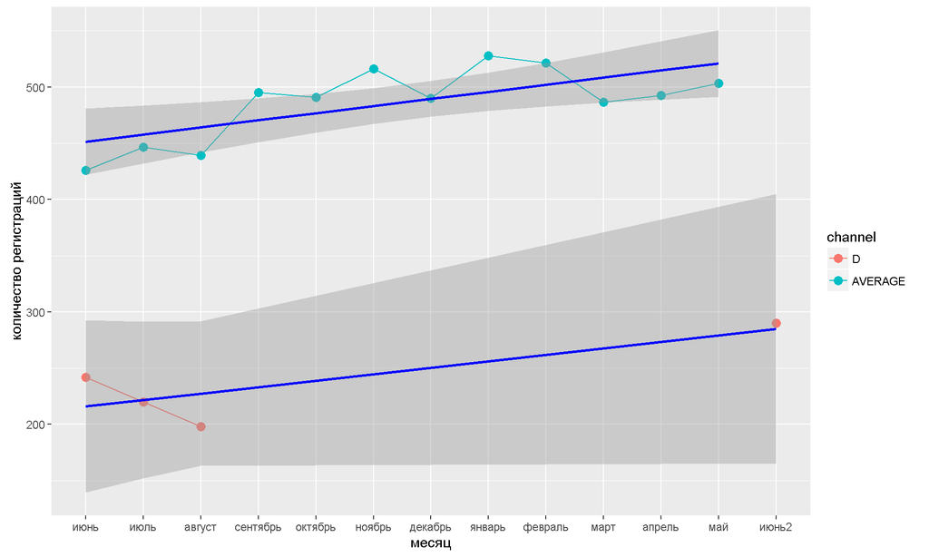